# TBI dynamic FC

Ben Cowley

17 March 2019

# PARAMETERS

```r
# data-type parameters
basepath <- 'data'
EXT <- 'csv'
# List of conditions
timecond <- c('pre', 'post')
# sliding window parameters
wndw <- 10
step <- wndw / 2 # 50% overlap steps
method <- "mean" # options are: max, mean, median, min, prod, sd, sum, var; see ?RcppRoll
REPS <- 10000
CND <- 1
```

# DATA WRANGLING

After exporting subject-wise ROIs from Matlab data to csv files, we read all data into a single long-format data structure. We label this data with the condition, 1 = pre, 2 = post

```r
# List of conditions

df <- read_all_recordings(basepath, pat='ROI_Subject0[0-9][0-9]_Condition000_mock', EXT)
df$cond <- rep(c(rep(1, 145), rep(2, 145)), 24)

subjs <- unique(df$Part)
sbjix <- seq(1, length(subjs))
```

# SYNCHRONY COMBINATIONS

Firstly, we work within each ROI combination indicated:

- roi 1 R IFG v roi 2 L HPC x cond 1
- roi 1 R IFG v roi 2 R NAC x cond 1
- roi 1 R ACC v roi 2 L STG x cond 1
- roi 1 R ACC v roi 2 R TPO x cond 1
- roi 1 R IFG v roi 2 L HPC x cond 2
- roi 1 R IFG v roi 2 R NAC x cond 2
- roi 1 R ACC v roi 2 L STG x cond 2
- roi 1 R ACC v roi 2 R TPO x cond 2

To aggregate correlations, we take the mean (note that correlations can only be aggregated this way for constant N; to see why, note that Hunter-Schmidt correlation aggregate is equivalent to average for constant N). We also take the mean of absolute correlations, to estimate the unsigned magnitude of connectivity (but this is not used yet).

We finally plot the correlation matrix for each combination.

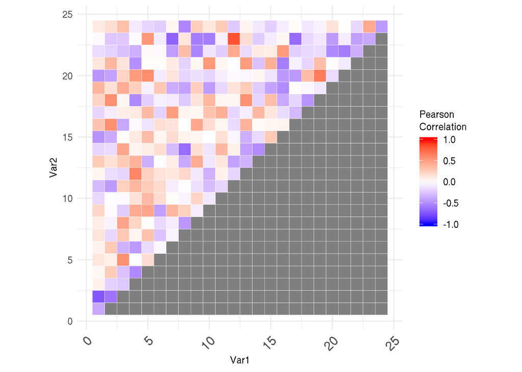

```r
# s1c1.rifg.lhpc <- corr_rollme(df, 1, 1, c("roi1_rifg", "roi2_lhpc"), 10, 5)
# c1All.rifg.lhpc <- corr_rollme_all(df, 1, c("roi1_rifg", "roi2_lhpc"), 10, 5)
# c2all.rifg.lhpc <- corr_rollme_all(df, 2, c("roi1_rifg", "roi2_lhpc"), 10, 5)

# PRE - TESTS
#####################################

# ROI 1 R IFG x ROI2 L HPC - COND1
all2allc1.rifg.lhpc <- corr_rollme_all2all(df, CND, c("roi1_rifg", "roi2_lhpc"), wndw, step, method)
allc1.rifg.lhpc <- diag(all2allc1.rifg.lhpc$corr)
avg.c1corr.rifg.lhpc <- mean(allc1.rifg.lhpc)
ab.av.c1cor.rifg.lhpc <- mean(abs(allc1.rifg.lhpc))
plot_rwb_cormat(all2allc1.rifg.lhpc$corr)
```

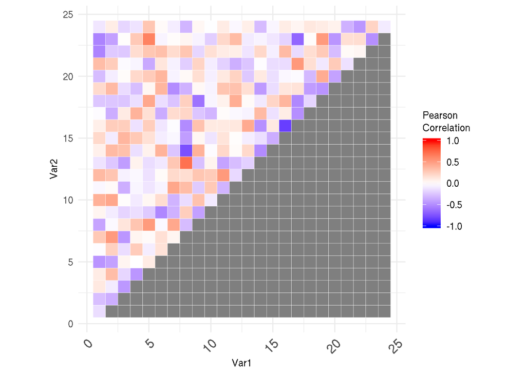

```r
# ROI 1 R IFG x ROI2 R NAC - COND1
all2allc1.rifg.rnac <- corr_rollme_all2all(df, CND, c("roi1_rifg", "roi2_rnac"), wndw, step, method)
allc1.rifg.rnac <- diag(all2allc1.rifg.rnac$corr)
avg.c1corr.rifg.rnac <- mean(allc1.rifg.rnac)
ab.av.c1cor.rifg.rnac <- mean(abs(allc1.rifg.rnac))
plot_rwb_cormat(all2allc1.rifg.rnac$corr)
```

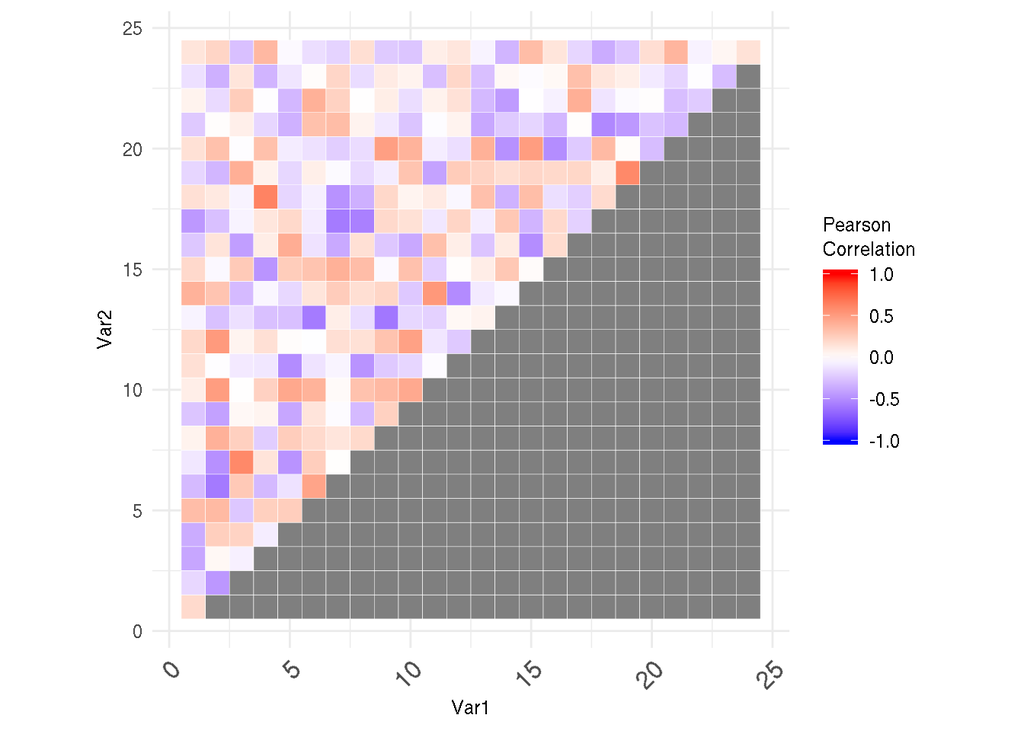

```r
# ROI 1 R ACC x ROI2 L STG - COND1
all2allc1.racc.lstg <- corr_rollme_all2all(df, CND, c("roi1_racc", "roi2_lstg"), wndw, step, method)
allc1.racc.lstg <- diag(all2allc1.racc.lstg$corr)
avg.c1corr.racc.lstg <- mean(allc1.racc.lstg)
ab.av.c1cor.racc.lstg <- mean(abs(allc1.racc.lstg))
plot_rwb_cormat(all2allc1.racc.lstg$corr)
```

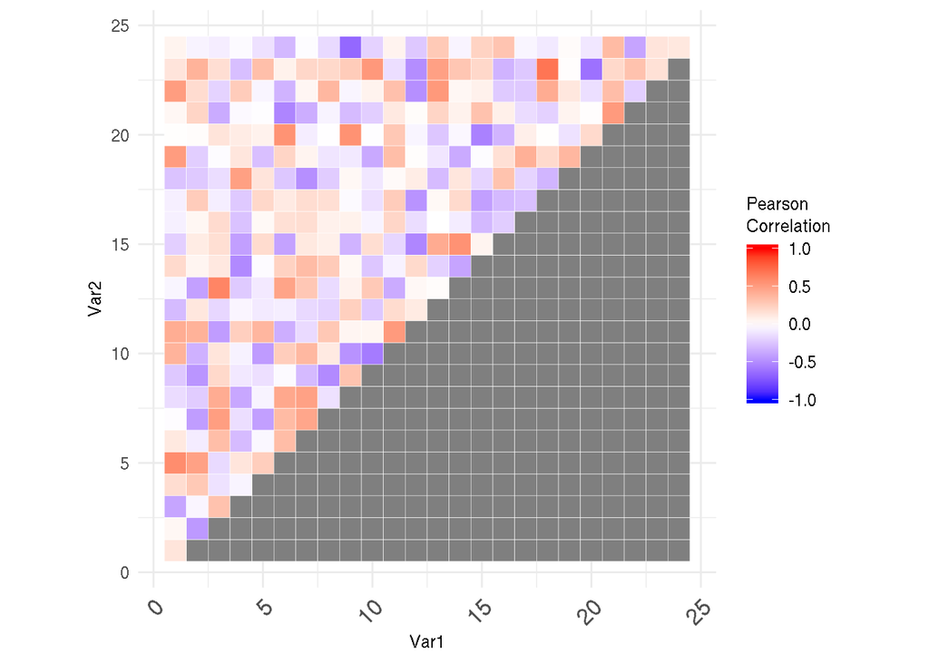

```r
# ROI 1 R ACC x ROI2 R TPO - COND1
all2allc1.racc.rtpo <- corr_rollme_all2all(df, CND, c("roi1_racc", "roi2_rtpo"), wndw, step, method)
allc1.racc.rtpo <- diag(all2allc1.racc.rtpo$corr)
avg.c1corr.racc.rtpo <- mean(allc1.racc.rtpo)
ab.av.c1cor.racc.rtpo <- mean(abs(allc1.racc.rtpo))
plot_rwb_cormat(all2allc1.racc.rtpo$corr)
```

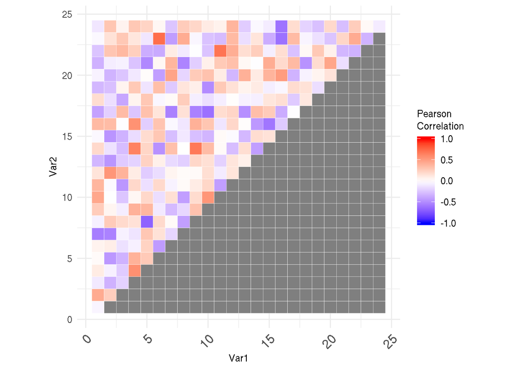

```r
# POST - TESTS
#####################################
CND = 2

# ROI 1 R IFG x ROI2 L HPC - Cond2
all2allc2.rifg.lhpc <- corr_rollme_all2all(df, CND, c("roi1_rifg", "roi2_lhpc"), wndw, step, method)
allc2.rifg.lhpc <- diag(all2allc2.rifg.lhpc$corr)
avg.c2corr.rifg.lhpc <- mean(allc2.rifg.lhpc)
ab.av.c2cor.rifg.lhpc <- mean(abs(allc2.rifg.lhpc))
plot_rwb_cormat(all2allc2.rifg.lhpc$corr)
```

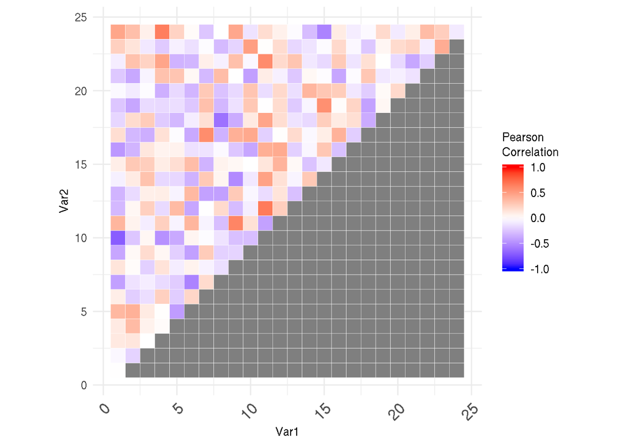

```r
# ROI 1 R IFG x ROI2 R NAC - Cond2
all2allc2.rifg.rnac <- corr_rollme_all2all(df, CND, c("roi1_rifg", "roi2_rnac"), wndw, step, method)
allc2.rifg.rnac <- diag(all2allc2.rifg.rnac$corr)
avg.c2corr.rifg.rnac <- mean(allc2.rifg.rnac)
ab.av.c2cor.rifg.rnac <- mean(abs(allc2.rifg.rnac))
plot_rwb_cormat(all2allc2.rifg.rnac$corr)
```

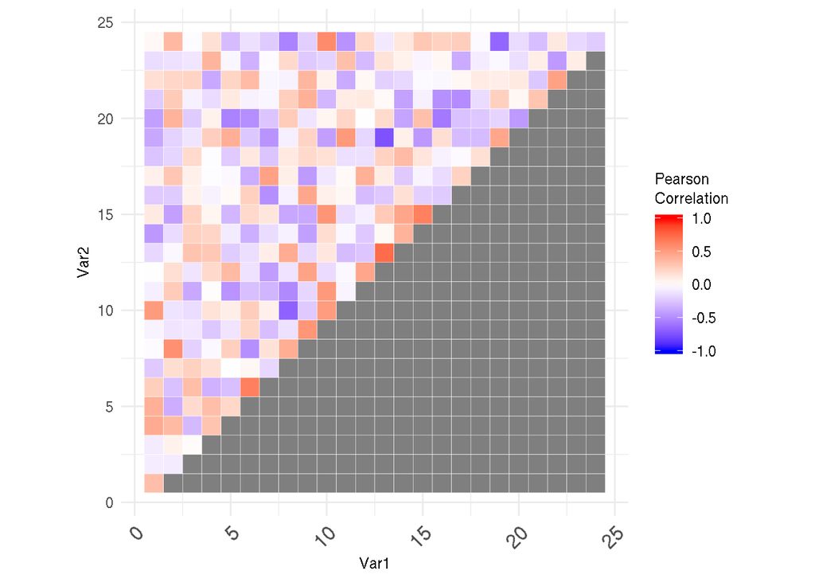

```r
# ROI 1 R ACC x ROI2 L STG - Cond2
all2allc2.racc.lstg <- corr_rollme_all2all(df, CND, c("roi1_racc", "roi2_lstg"), wndw, step, method)
allc2.racc.lstg <- diag(all2allc2.racc.lstg$corr)
avg.c2corr.racc.lstg <- mean(allc2.racc.lstg)
ab.av.c2cor.racc.lstg <- mean(abs(allc2.racc.lstg))
plot_rwb_cormat(all2allc2.racc.lstg$corr)
```

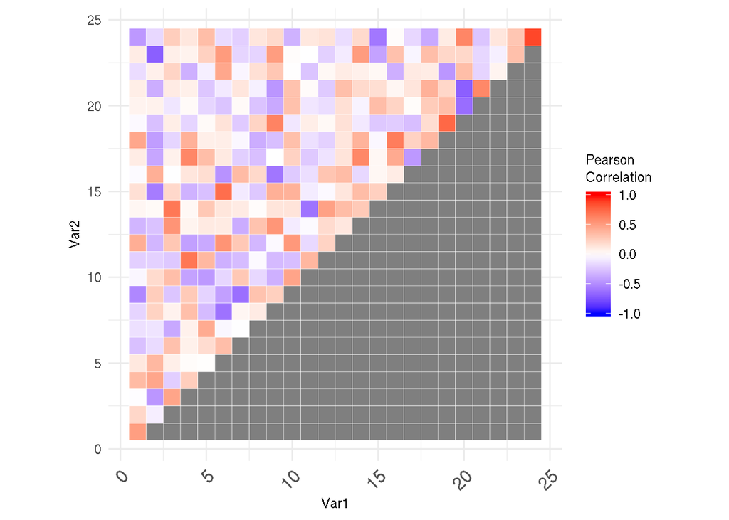

```r
# ROI 1 R ACC x ROI2 R TPO - Cond2
all2allc2.racc.rtpo <- corr_rollme_all2all(df, CND, c("roi1_racc", "roi2_rtpo"), wndw, step, method)
allc2.racc.rtpo <- diag(all2allc2.racc.rtpo$corr)
avg.c2corr.racc.rtpo <- mean(allc2.racc.rtpo)
ab.av.c2cor.racc.rtpo <- mean(abs(allc2.racc.rtpo))
plot_rwb_cormat(all2allc2.racc.rtpo$corr)
```

# MATRIX SAMPLING

To obtain a random sample (without replacement) of the pair-wise correlations, we simply shuffle the columns of each correlation matrix, which means we destroy matrix symmetry. An example is calculated and displayed below.

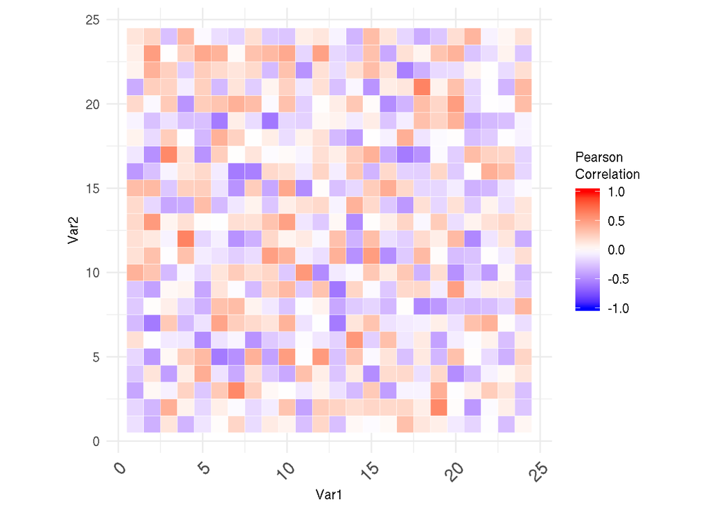

```r
samp <- sample_matrix(sbjix, all2allc1.racc.lstg$corr, repl = FALSE)
plot_rwb_cormat(samp$sampmat)
```

# PERMUTATION TESTING

To obtain a permutation test statistic, we repeat the random sampling 10000 times, generating a distribution of correlations. We plot the observed real correlation against the distribution to see the statistical difference of the obervation from a random distribution; actual *p*-value is computed by counting the proportion of random samples which lie *beyond* the observation, i.e. are absolutely greater. It is significantly different in 4 of 8 cases here: the underlying pattern seems to be that correlations increase during the intervention, comparing pre-test to post-test.

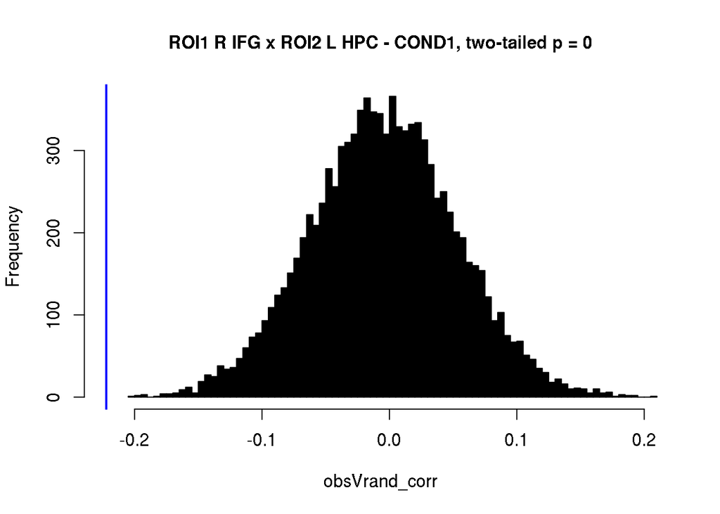

```r
# PRE - TESTS
#####################################
# ROI1 R IFG x ROI2 L HPC - COND1
obsVrand_corr <- replicate(REPS, sampmat_diag_stat(mean, sbjix, all2allc1.rifg.lhpc$corr))
hist(obsVrand_corr, xlim = range(obsVrand_corr, avg.c1corr.rifg.lhpc), col='black', breaks=100,
     main = paste("ROI1 R IFG x ROI2 L HPC - COND1, two-tailed p =", sum(abs(obsVrand_corr) > abs(avg.c1corr.rifg.lhpc)) / REPS))
abline(v=avg.c1corr.rifg.lhpc, col='blue', lwd=2)
```

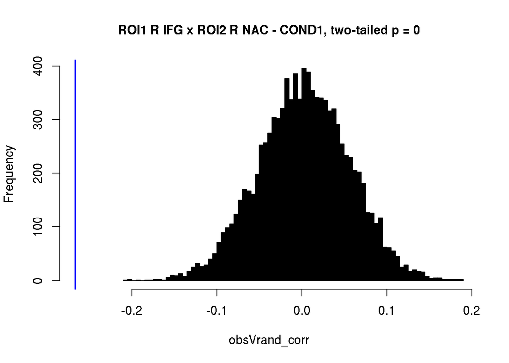

```r
# ROI1 R IFG x ROI2 R NAC - COND1
obsVrand_corr <- replicate(REPS, sampmat_diag_stat(mean, sbjix, all2allc1.rifg.rnac$corr))
hist(obsVrand_corr, xlim = range(obsVrand_corr, avg.c1corr.rifg.rnac), col='black', breaks=100,
     main = paste("ROI1 R IFG x ROI2 R NAC - COND1, two-tailed p =", sum(abs(obsVrand_corr) > abs(avg.c1corr.rifg.rnac)) / REPS))
abline(v=avg.c1corr.rifg.rnac, col='blue', lwd=2)
```

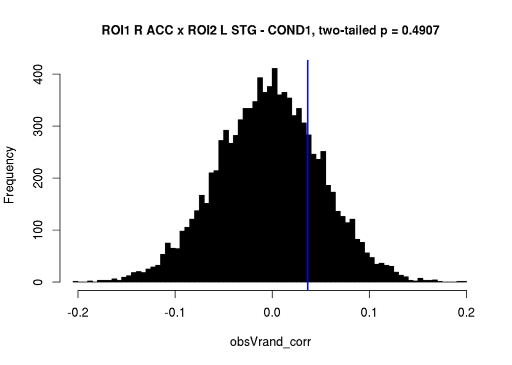

```r
# ROI1 R ACC x ROI2 L STG - COND1
obsVrand_corr <- replicate(REPS, sampmat_diag_stat(mean, sbjix, all2allc1.racc.lstg$corr))
hist(obsVrand_corr, xlim = range(obsVrand_corr, avg.c1corr.racc.lstg), col='black', breaks=100,
     main = paste("ROI1 R ACC x ROI2 L STG - COND1, two-tailed p =", sum(abs(obsVrand_corr) > abs(avg.c1corr.racc.lstg)) / REPS))
abline(v=avg.c1corr.racc.lstg, col='blue', lwd=2)
```

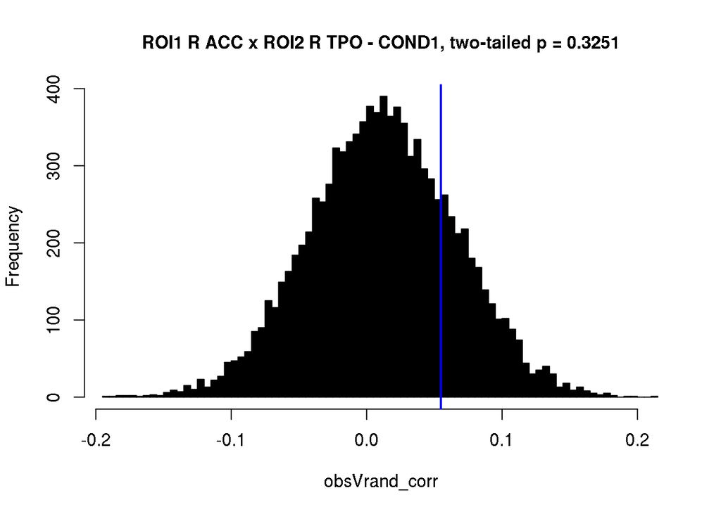

```r
# ROI1 R ACC x ROI2 R TPO - COND1
obsVrand_corr <- replicate(REPS, sampmat_diag_stat(mean, sbjix, all2allc1.racc.rtpo$corr))
hist(obsVrand_corr, xlim = range(obsVrand_corr, avg.c1corr.racc.rtpo), col='black', breaks=100,
     main = paste("ROI1 R ACC x ROI2 R TPO - COND1, two-tailed p =", sum(abs(obsVrand_corr) > abs(avg.c1corr.racc.rtpo)) / REPS))
abline(v=avg.c1corr.racc.rtpo, col='blue', lwd=2)
```

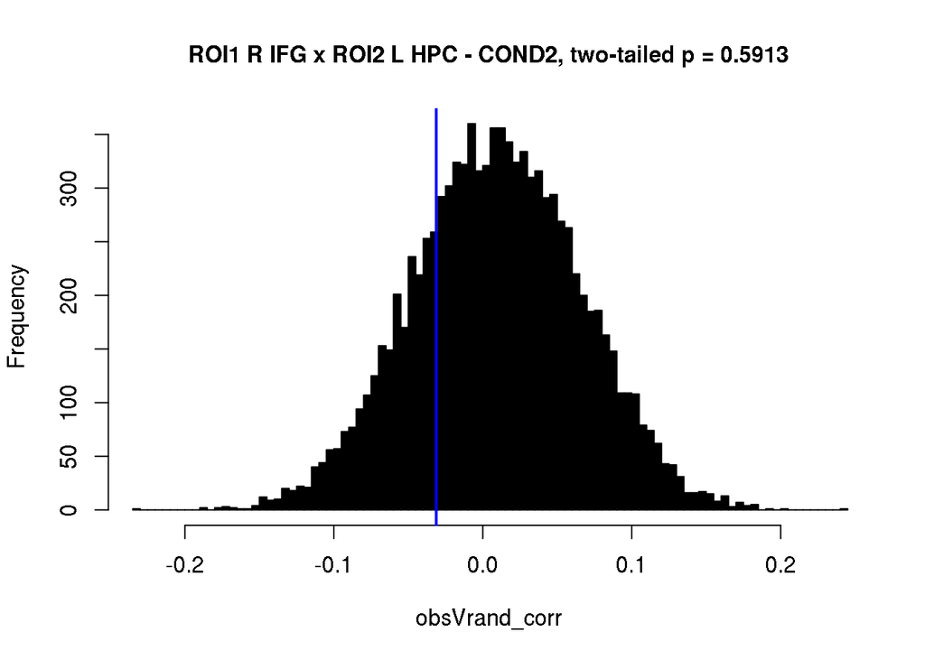

```r
# POST - TESTS
#####################################
# ROI1 R IFG x ROI2 L HPC - COND2
obsVrand_corr <- replicate(REPS, sampmat_diag_stat(mean, sbjix, all2allc2.rifg.lhpc$corr))
hist(obsVrand_corr, xlim = range(obsVrand_corr, avg.c2corr.rifg.lhpc), col='black', breaks=100,
     main = paste("ROI1 R IFG x ROI2 L HPC - COND2, two-tailed p =", sum(abs(obsVrand_corr) > abs(avg.c2corr.rifg.lhpc)) / REPS))
abline(v=avg.c2corr.rifg.lhpc, col='blue', lwd=2)
```

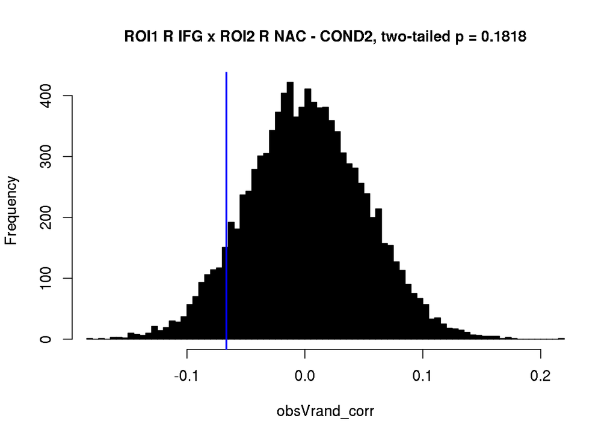

```r
# ROI1 R IFG x ROI2 R NAC - COND2
obsVrand_corr <- replicate(REPS, sampmat_diag_stat(mean, sbjix, all2allc2.rifg.rnac$corr))
hist(obsVrand_corr, xlim = range(obsVrand_corr, avg.c2corr.rifg.rnac), col='black', breaks=100,
     main = paste("ROI1 R IFG x ROI2 R NAC - COND2, two-tailed p =", sum(abs(obsVrand_corr) > abs(avg.c2corr.rifg.rnac)) / REPS))
abline(v=avg.c2corr.rifg.rnac, col='blue', lwd=2)
```

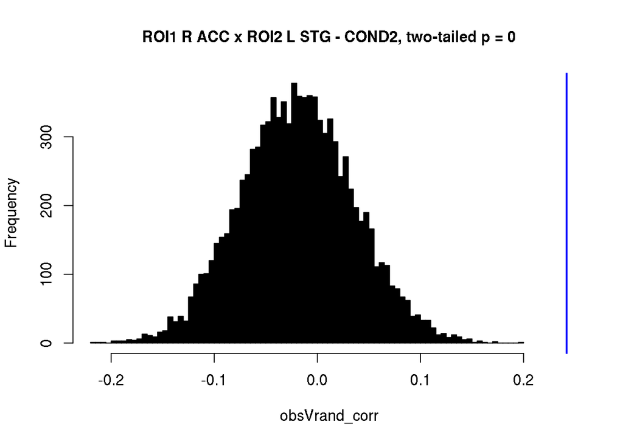

```r
# ROI1 R ACC x ROI2 L STG - COND2
obsVrand_corr <- replicate(REPS, sampmat_diag_stat(mean, sbjix, all2allc2.racc.lstg$corr))
hist(obsVrand_corr, xlim = range(obsVrand_corr, avg.c2corr.racc.lstg), col='black', breaks=100,
     main = paste("ROI1 R ACC x ROI2 L STG - COND2, two-tailed p =", sum(abs(obsVrand_corr) > abs(avg.c2corr.racc.lstg)) / REPS))
abline(v=avg.c2corr.racc.lstg, col='blue', lwd=2)
```

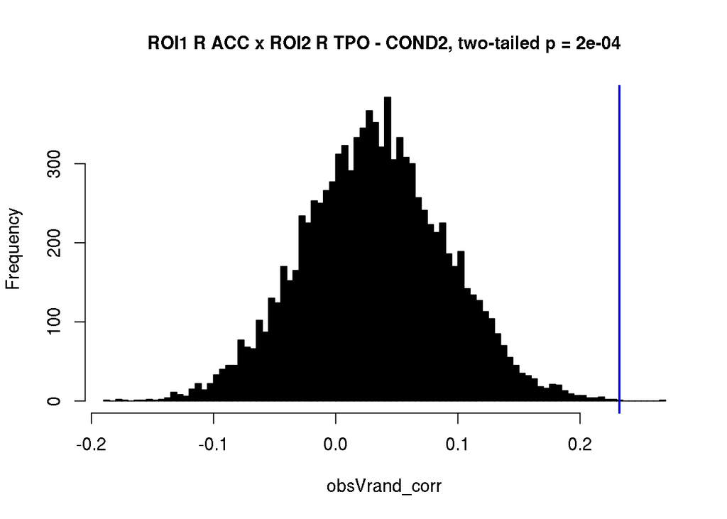

```r
# ROI1 R ACC x ROI2 R TPO - COND2
obsVrand_corr <- replicate(REPS, sampmat_diag_stat(mean, sbjix, all2allc2.racc.rtpo$corr))
hist(obsVrand_corr, xlim = range(obsVrand_corr, avg.c2corr.racc.rtpo), col='black', breaks=100,
     main = paste("ROI1 R ACC x ROI2 R TPO - COND2, two-tailed p =", sum(abs(obsVrand_corr) > abs(avg.c2corr.racc.rtpo)) / REPS))
abline(v=avg.c2corr.racc.rtpo, col='blue', lwd=2)
```

# TESTING PRE-POST

Are the change of correlations from condition 1 to condition 2 significant? Testing by one-sample t-test and one-sample permutation test, we get similar results by each method.

```r
t.test(allc2.racc.lstg - allc1.racc.lstg)
```

```
##
##  One Sample t-test
##
## data:  allc2.racc.lstg - allc1.racc.lstg
## t = 3.0216, df = 23, p-value = 0.006075
## alternative hypothesis: true mean is not equal to 0
## 95 percent confidence interval:
##  0.06471748 0.34570837
## sample estimates:
## mean of x
## 0.2052129
```

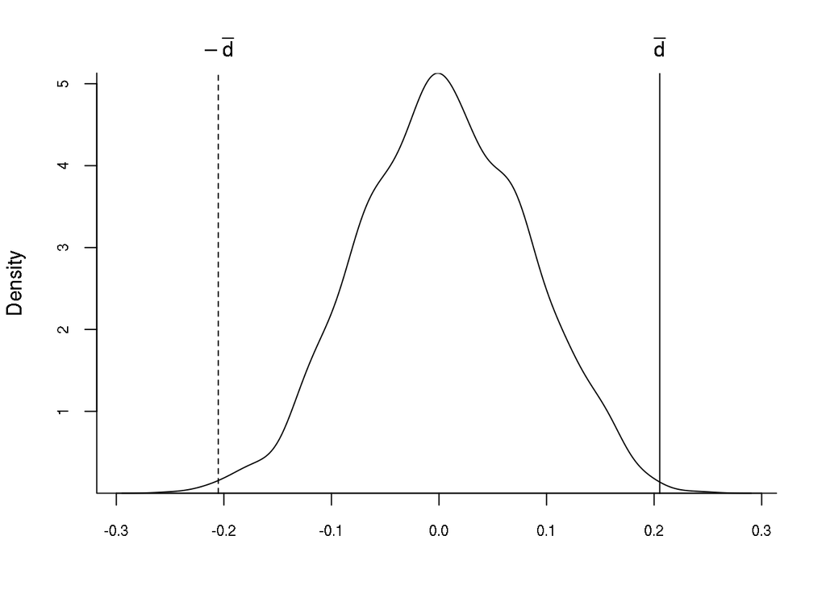

```
## [1] 0.0035
```

```r
onet.permutation(allc2.racc.lstg - allc1.racc.lstg)
```

```r
t.test(allc2.racc.rtpo - allc1.racc.rtpo)
```

```
##
##  One Sample t-test
##
## data:  allc2.racc.rtpo - allc1.racc.rtpo
## t = 2.1791, df = 23, p-value = 0.03982
## alternative hypothesis: true mean is not equal to 0
## 95 percent confidence interval:
##  0.008988389 0.345786855
## sample estimates:
## mean of x
## 0.1773876
```

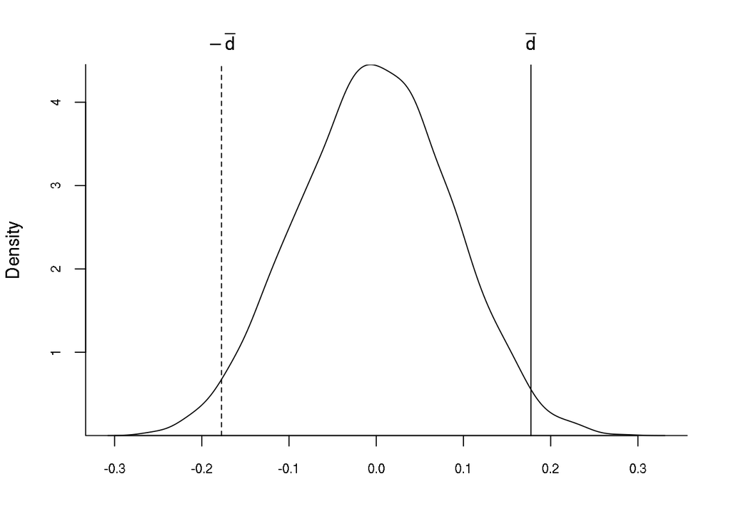

```
## [1] 0.033
```

```r
onet.permutation(allc2.racc.rtpo - allc1.racc.rtpo)
```

```r
t.test(allc2.rifg.lhpc - allc1.rifg.lhpc)
```

```
##
##  One Sample t-test
##
## data:  allc2.rifg.lhpc - allc1.rifg.lhpc
## t = 2.6118, df = 23, p-value = 0.01559
## alternative hypothesis: true mean is not equal to 0
## 95 percent confidence interval:
##  0.03970708 0.34219522
## sample estimates:
## mean of x
## 0.1909511
```

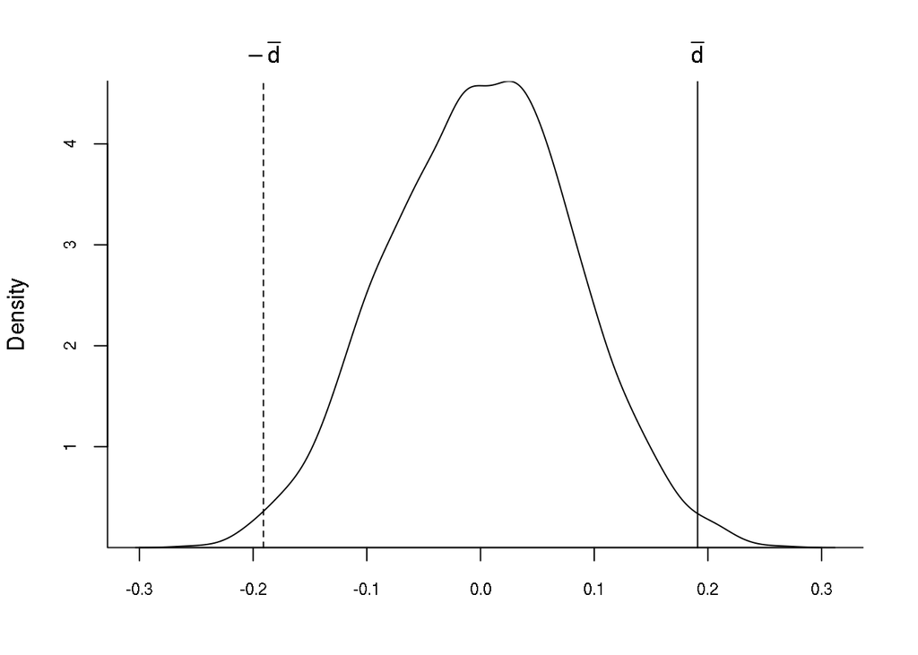

```
## [1] 0.017
```

```r
onet.permutation(allc2.rifg.lhpc - allc1.rifg.lhpc)
```

```r
t.test(allc2.rifg.rnac - allc1.rifg.rnac)
```

```
##
##  One Sample t-test
##
## data:  allc2.rifg.rnac - allc1.rifg.rnac
## t = 2.8568, df = 23, p-value = 0.008922
## alternative hypothesis: true mean is not equal to 0
## 95 percent confidence interval:
##  0.05522119 0.34510189
## sample estimates:
## mean of x
## 0.2001615
```

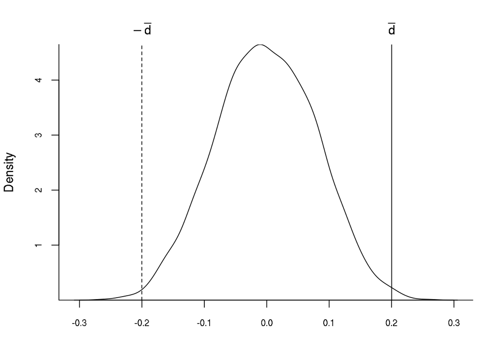

```
## [1] 0.007
```

```r
onet.permutation(allc2.rifg.rnac - allc1.rifg.rnac)
```